# Analysis of Genotyping Array Data from Human Pancreatic Islets

PI Charlotte Ling, Lund University

Nikolay Oskolkov, SciLifeLab, NBIS Long Term Support, nikolay.oskolkov@scilifelab.se

January 14, 2020

Abstract

Here we will use the genotyping array data from Human Pancreatic Islets from individuals with and without Type 2 Diabetes (T2D) and perform diebetes status linear predictive analysis with PLS-DA model on 110 manually selected individuals with most reliable phenotypic information.

### The List of 110 Selected Individuals

All the analysis will be performed on the 110 individuals whic were selected based on multiple criteria such as 1) they are either normo-glycimic or hyper-glycemic / T2D individuals, 2) they have information from all the 4 OMICS (methylation, transcriptomics, phenotypes, genotypes), 3) they all fall within the same age category, and a few other minor criteria. Now we will read the list of those 110 individuals and display a few of them:

```r
set.seed(1)
selected_ind<-scan("OVERLAPPING_110_SAMPLES_4OMICS.txt", what = "charater")
selected_ind<-paste0("ID",selected_ind)
print(head(selected_ind, 20))
```

```
##  [1] "ID1"  "ID3"  "ID4"  "ID6"  "ID8"  "ID10" "ID14" "ID19" "ID21" "ID30"
## [11] "ID32" "ID34" "ID35" "ID36" "ID38" "ID39" "ID44" "ID46" "ID55" "ID58"
```

```r
print(tail(selected_ind, 20))
```

```
##  [1] "ID136" "ID156" "ID160" "ID165" "ID168" "ID172" "ID175" "ID182"
##  [9] "ID183" "ID191" "ID194" "ID200" "ID209" "ID210" "ID214" "ID217"
## [17] "ID221" "ID228" "ID263" "ID273"
```

### Checking Human Islets Phenotypes

We will start with the analysis of phenotypes available from approximately 300 Human Panctreatic Islets in order to check the relation between the phenotypes. Later this information will be taken into account when we do batch-effects correction. The phenotype file below was provided by Human Tissue Lab (HTL) from Lund University Diabetes Center (LUDC), it includes phenotypic information from approximately 300 pancreatic islets donors. Not all of them will overlap with the methylation array, RNAseq and genotyping array samples but we still will use the info from all available donors in order to establish how phenotypes are correlated with each other. We start with reading the file and removing non-relevant phenotypes:

- HTL_donor_ID: Human Tissue Lab Donor ID)
- NICS_donor_ID: Uppsala donor ID
- Birth: redundant, captured by Age variable
- HbA1c_mmol_mol: redundant, captured by HbA1c_perc
- Blood_group: unlikely to be related to Type 2 Diabetes
- Non_diabetic: redundant, captured by T2D variable
- GAD: not related to T2D
- Gestational: appropriate only for females, will be correlated with Sex
- Date_isolated_islets: unlikely to be related to Type 2 Diabetes
- Date_recieved_islets: unlikely to be related to Type 2 Diabetes
- Islet_equivalences: unlikely to be related to Type 2 Diabetes
- Diabetes_treatment: too sparse information

We will also add information about Methylation EPIC Array batches and RNAseq batches (old vs. new chemistry) in order to see what phenotypes the batches correlate with. This is a potential danger if the batches happen to correlate with valuables phenotypes like T2D or HbA1c. As a control of noise level we will introduce a random variable, we will use it to check later how much of phenotypic variation can be explained by chance.

```r
htl<-read.csv("htl_donors.csv",header=TRUE,check.names=FALSE)
htl$HTL_donor_ID<-paste0("ID",htl$HTL_donor_ID)
phen_meth_batch<-read.delim("phenotypes_islets.txt",header=TRUE,row.names=1,check.names=FALSE,sep="\t")
htl$Meth_Batch<-phen_meth_batch$batch[match(as.character(htl$HTL_donor_ID),rownames(phen_meth_batch))]
htl$Meth_Batch[is.na(htl$Meth_Batch)]<-21
phen_rnaseq_batch<-read.delim("phen_rnaseq_batch.txt",header=TRUE,row.names=1,check.names=FALSE,sep="\t")
htl$RNA_Batch<-phen_rnaseq_batch$batch[match(as.character(htl$HTL_donor_ID),rownames(phen_rnaseq_batch))]
htl$Random<-log(sample(dim(htl)[1]))
rownames(htl)<-htl$HTL_donor_ID

htl$HTL_donor_ID<-NULL
htl$NICS_donor_ID<-NULL
htl$Birth<-NULL
htl$HbA1c_mmol_mol<-NULL
htl$Blood_group<-NULL
htl$Non_diabetic<-NULL
htl$GAD<-NULL
htl$Gestational<-NULL
htl$Date_isolated_islets<-NULL
htl$Date_recieved_islets<-NULL
htl$Islet_equivalences<-NULL
htl$Diabetes_treatment<-NULL
head(htl)
```

```
##     Gender Age  BMI HbA1c_perc T2D Stimulatory_index Purity_perc
## ID1   Male  68 24.7        5.8   0               9.6          75
## ID2   Male  55 24.7         NA   0              10.2          90
## ID3 Female  45 23.9        5.4   0               3.6          70
## ID4 Female  61 27.7         NA   0              14.9          80
## ID5 Female  69 17.6         NA   0              10.9          37
## ID6   Male  67 28.4        5.5   0               1.9          95
##     Days_cultured Meth_Batch RNA_Batch   Random
## ID1             5          1  old_chem 5.117994
## ID2             8         21  old_chem 4.859812
## ID3             3          1  old_chem 5.598422
## ID4             5         21  old_chem 5.231109
## ID5             2         21  old_chem 4.442651
## ID6             2          1  old_chem 5.624018
```

For convenience we will rename HbA1c_perc to HbA1c, Stimulatory_index to SI, Purity_perc to Purity, Days_cultured to DIC. We will also assign donors with HbA1c > 6.5 to diabetics and balance the data set a bit better in this way.

```r
names(htl)[names(htl)=="HbA1c_perc"]<-"HbA1c"
names(htl)[names(htl)=="Stimulatory_index"]<-"SI"
names(htl)[names(htl)=="Purity_perc"]<-"Purity"
names(htl)[names(htl)=="Days_cultured"]<-"DIC"
htl$T2D<-ifelse( ((is.na(htl$T2D)==FALSE & htl$T2D==1) | (is.na(htl$HbA1c)==FALSE  & htl$HbA1c>6.5)), 1, 0)
head(htl)
```

```
##     Gender Age  BMI HbA1c T2D   SI Purity DIC Meth_Batch RNA_Batch
## ID1   Male  68 24.7   5.8   0  9.6     75   5          1  old_chem
## ID2   Male  55 24.7    NA   0 10.2     90   8         21  old_chem
## ID3 Female  45 23.9   5.4   0  3.6     70   3          1  old_chem
## ID4 Female  61 27.7    NA   0 14.9     80   5         21  old_chem
## ID5 Female  69 17.6    NA   0 10.9     37   2         21  old_chem
## ID6   Male  67 28.4   5.5   0  1.9     95   2          1  old_chem
##       Random
## ID1 5.117994
## ID2 4.859812
## ID3 5.598422
## ID4 5.231109
## ID5 4.442651
## ID6 5.624018
```

```r
for(i in 1:ncol(htl))
{
  if(length(levels(factor(htl[,i]))) > 2)
  {
    htl[,i]<-as.numeric(as.character(htl[,i]))
  }
  else
  {
    htl[,i]<-as.factor(htl[,i])
  }
}
```

Now we are going to select the 110 individuals with overlapping OMICs and keep only those individuals for further downstream analysis:

```r
htl<-htl[match(selected_ind,rownames(htl)),]
head(htl)
```

```
##      Gender Age  BMI HbA1c T2D   SI Purity DIC Meth_Batch RNA_Batch
## ID1    Male  68 24.7   5.8   0  9.6     75   5          1  old_chem
## ID3  Female  45 23.9   5.4   0  3.6     70   3          1  old_chem
## ID4  Female  61 27.7    NA   0 14.9     80   5         21  old_chem
## ID6    Male  67 28.4   5.5   0  1.9     95   2          1  old_chem
## ID8    Male  51 27.0   4.3   0 37.3     75   2         14  old_chem
## ID10 Female  60 26.1    NA   0  5.6     75   2         21  old_chem
##        Random
## ID1  5.117994
## ID3  5.598422
## ID4  5.231109
## ID6  5.624018
## ID8  4.369448
## ID10 3.610918
```

Now let us calculate pair-wise linear regression for the phenotypes and extract the adjusted R squared information which is equaivalent to the fraction of variation in the response variable explained by the predictor variable. In case the response variable is a factor, we will be using logistic regression (Generalized Linear Model, GLM, with family = “binomial”) and calculate the adjusted R suared as:

$$R^2_{adj} = 1 - \frac{\rm{Residual Deviance}}{\rm{Null Deviance}}$$

```r
htl_adj_r_squared<-matrix(NA,ncol=ncol(htl),nrow=ncol(htl))
for(i in 1:ncol(htl))
{
  print(i)
  for(j in 1:ncol(htl))
  {
    if(typeof(htl[,i])=="double" & (typeof(htl[,j])=="double" | typeof(htl[,j])=="integer"))
    {
      model<-suppressWarnings(lm(htl[,i]~htl[,j]))
      htl_adj_r_squared[j,i]<-suppressWarnings(summary(model)$adj.r.squared)
    }
    if(typeof(htl[,i])=="integer" & typeof(htl[,j])=="double")
    {
      model<-suppressWarnings(lm(htl[,j]~htl[,i]))
      htl_adj_r_squared[j,i]<-suppressWarnings(summary(model)$adj.r.squared)
    }
    if(typeof(htl[,i])=="integer" & typeof(htl[,j])=="integer")
    {
      model<-suppressWarnings(glm(htl[,i]~htl[,j],family="binomial"))
      htl_adj_r_squared[j,i]<-1-model$deviance/model$null.deviance
    }
  }
}
```

```
## [1] 1
## [1] 2
## [1] 3
## [1] 4
## [1] 5
## [1] 6
## [1] 7
## [1] 8
## [1] 9
## [1] 10
## [1] 11
```

```r
htl_adj_r_squared<-as.data.frame(htl_adj_r_squared)
colnames(htl_adj_r_squared)<-colnames(htl)
rownames(htl_adj_r_squared)<-colnames(htl)
htl_adj_r_squared[htl_adj_r_squared<0]<-0
htl_adj_r_squared
```

```
##                  Gender         Age         BMI      HbA1c          T2D
## Gender     1.0000000000 0.000000000 0.000000000 0.00000000 6.709567e-05
## Age        0.0000000000 1.000000000 0.000000000 0.00000000 0.000000e+00
## BMI        0.0000000000 0.000000000 1.000000000 0.02101267 3.241738e-02
## HbA1c      0.0000000000 0.000000000 0.021012675 1.00000000 5.635442e-01
## T2D        0.0000608413 0.000000000 0.032417382 0.56354416 1.000000e+00
## SI         0.0047175889 0.000000000 0.000000000 0.01691996 4.099784e-03
## Purity     0.0000000000 0.000000000 0.000000000 0.00000000 0.000000e+00
## DIC        0.0000000000 0.011359304 0.000000000 0.03419322 7.579456e-02
## Meth_Batch 0.0000000000 0.005251804 0.000000000 0.00000000 0.000000e+00
## RNA_Batch  0.0022531214 0.000000000 0.000000000 0.00000000 2.053184e-02
## Random     0.0000000000 0.000000000 0.001175757 0.00000000 7.923939e-03
##                     SI      Purity         DIC  Meth_Batch  RNA_Batch
## Gender     0.004717589 0.000000000 0.000000000 0.000000000 0.00262000
## Age        0.000000000 0.000000000 0.011359304 0.005251804 0.00000000
## BMI        0.000000000 0.000000000 0.000000000 0.000000000 0.00000000
## HbA1c      0.016919962 0.000000000 0.034193217 0.000000000 0.00000000
## T2D        0.004099784 0.000000000 0.075794563 0.000000000 0.01798873
## SI         1.000000000 0.000000000 0.000000000 0.017228281 0.08353539
## Purity     0.000000000 1.000000000 0.067372444 0.004887090 0.04538269
## DIC        0.000000000 0.067372444 1.000000000 0.004515378 0.00000000
## Meth_Batch 0.017228281 0.004887090 0.004515378 1.000000000 0.05496894
## RNA_Batch  0.083535390 0.045382693 0.000000000 0.054968938 1.00000000
## Random     0.011848277 0.002161258 0.000000000 0.000000000 0.02205427
##                 Random
## Gender     0.000000000
## Age        0.000000000
## BMI        0.001175757
## HbA1c      0.000000000
## T2D        0.007923939
## SI         0.011848277
## Purity     0.002161258
## DIC        0.000000000
## Meth_Batch 0.000000000
## RNA_Batch  0.022054271
## Random     1.000000000
```

Now we can plot the heatmap of the adjusted R squared statistics and check how phenotypes and batches are related to each other:

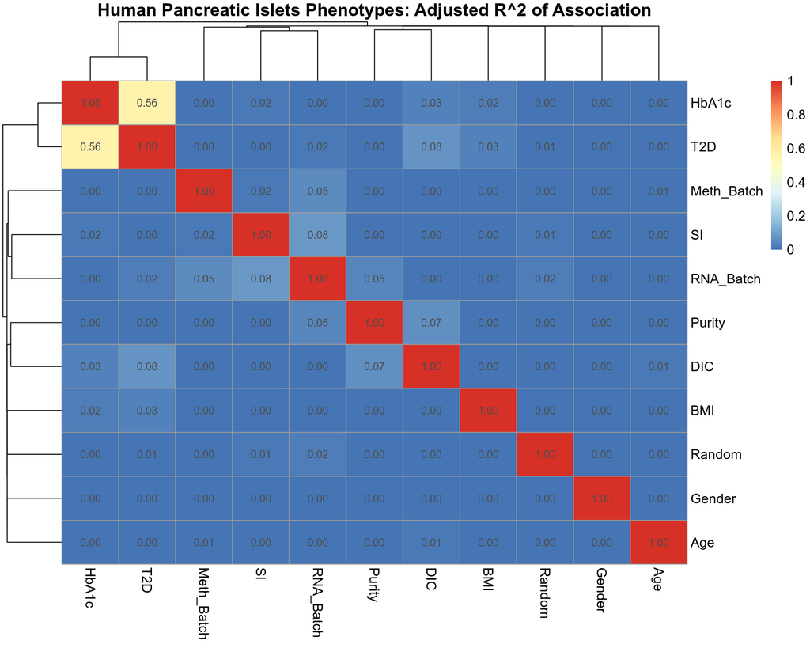

```r
library("pheatmap")
pheatmap(htl_adj_r_squared, display_numbers=TRUE, fontsize=12, main="Human Pancreatic Islets Phenotypes: Adjusted R^2 of Association")
```

We can see that HbA1c and T2D are very strongly connected, they should since the T2D diagnostics relies on blood glucose level measurements. They also weakly cluster together with BMI implying relation between those three phenotypes, which also makes a lot of sense. Despite Age and Gender are believed to be a risk factor for T2D, we do not observe a reliable association between those three phenotypes in our sample. Meth_Batch and RNA_Batch are moderately connected but happily do not seem to influence any of the important phenotypes, perhaps only the Stimulatory Index (SI). There is one more strange / unexpected observations following from the heatmap: DIC seem to be strangly but weakly correlated with the T2D status.

### Genotype Data from Human Pancreatic Islets

Let us read the matrix of genotypes and have a look at the data. In this analysis due to the small sample size we will use only common variants, i.e. with MAF>=5%, and variants with zero missingness, i.e. present in all individuals:

```r
library("data.table")
gen<-data.frame(fread("islets_1_to_286_additive.raw",header=TRUE,sep=" "),row.names=1,check.names=FALSE)
gen$IID<-NULL
gen$PAT<-NULL
gen$MAT<-NULL
gen$SEX<-NULL
gen$PHENOTYPE<-NULL
gen<-as.data.frame(t(gen))
colnames(gen)<-gsub("HTL000","",colnames(gen))
colnames(gen)<-gsub("HTL00","",colnames(gen))
colnames(gen)<-gsub("HTL0","",colnames(gen))
colnames(gen)<-paste0("ID",colnames(gen))
#gen[,c("ID41","ID68","ID117","ID193","ID135","ID161","ID166")]<-NULL #remove population outliers
gen[1:5,1:5]
```

```
##              ID33_dup ID238 ID239 ID240 ID241
## rs10127827_0        0     0     0     0     0
## rs10162780_0        0     0     0     0     0
## rs10188129_0        0     0     0     0     0
## rs10226025_0        0     0     0     0     0
## rs10232915_0        0     0     0     0     0
```

```r
dim(gen)
```

```
## [1] 271343    281
```

We will prefilter the matrix of genotypes by excluding monomorphic variants and variants close to monomorphic, i.e. with one genotype dominating, i.e. with variance across individuals close to zero:

```r
library("matrixStats")
library("mixOmics")
```

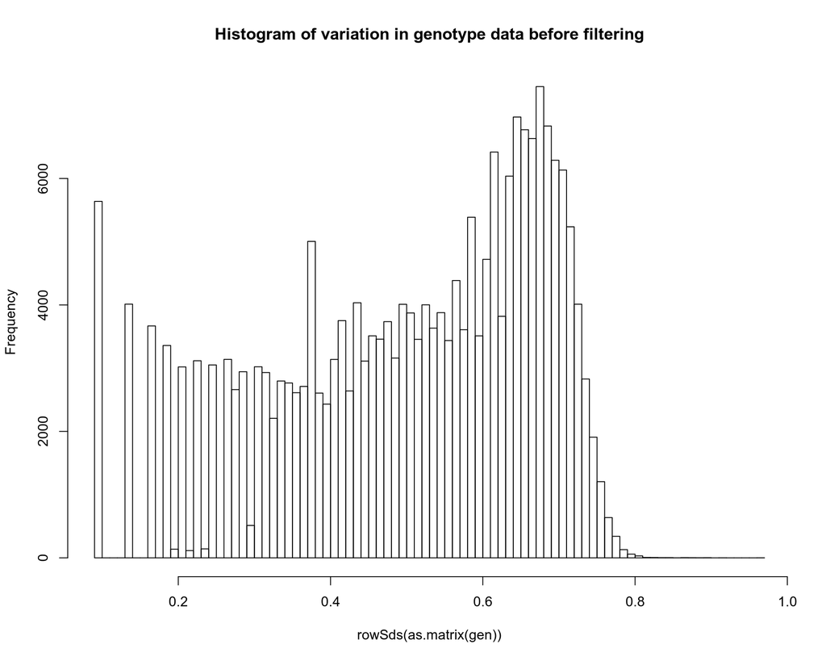

```r
gen<-subset(gen,select=selected_ind)
#gen<-gen[rowSums(gen)!=0,] #exclude monomorphic variants, otherwise SVD will have troubles
gen<-gen[rowSds(as.matrix(gen))!=0,] #exclude monomorphic variants, otherwise SVD will have troubles

#my_nearZeroVar<-nearZeroVar(as.data.frame(t(gen)))
#head(my_nearZeroVar$Metrics)
#dim(my_nearZeroVar$Metrics)
#gen<-gen[-which(rownames(gen)%in%rownames(my_nearZeroVar$Metrics)),]

hist(rowSds(as.matrix(gen)), breaks = 100, main = "Histogram of variation in genotype data before filtering")
```

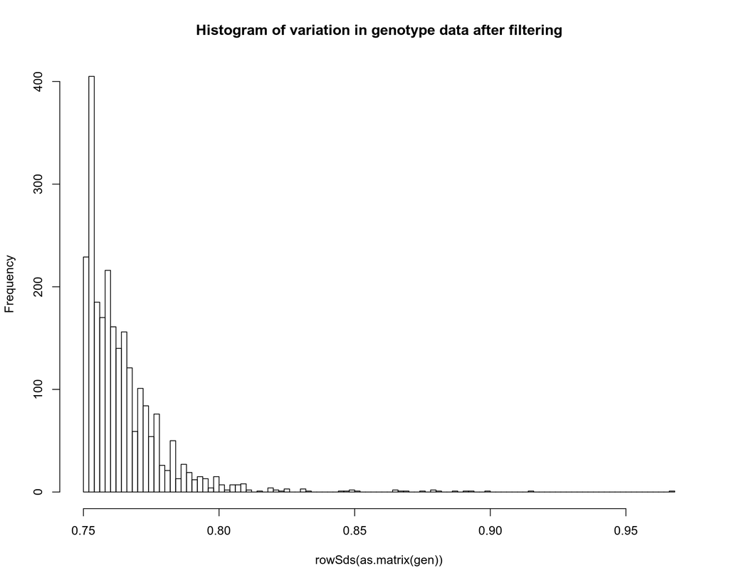

```r
gen<-gen[rowSds(as.matrix(gen))>=0.75,] #exclude variants close to monomorphic, i.e. one group dominates
hist(rowSds(as.matrix(gen)), breaks = 100, main = "Histogram of variation in genotype data after filtering")
```

```r
gen[1:5,1:5]
```

```
##              ID1 ID3 ID4 ID6 ID8
## rs1851946_A    0   1   2   0   2
## rs2455144_A    0   2   0   0   1
## rs2455137_G    0   2   0   0   1
## rs2500278_G    0   2   0   0   1
## rs12031275_G   2   0   2   0   0
```

```r
dim(gen)
```

```
## [1] 2445  110
```

Therefore we have 32 diabetics in the initial phenotype data set that matches the genotype data set.

Now the genotype and phenotype data are ready for analysis and we will start with a simple PCA in order to look at obvious batch effects. We will proceed then with Partial Least Squares regression and finally will use it for prediction of diabetes status.

### Preliminary Analysis with PCA

Now we will perform preliminary PCA analysis. Fo this purpose, the genotype matrix, which we will refer to as *X*, needs to be transposed. We will keep only top 10 PCs for evaluation.

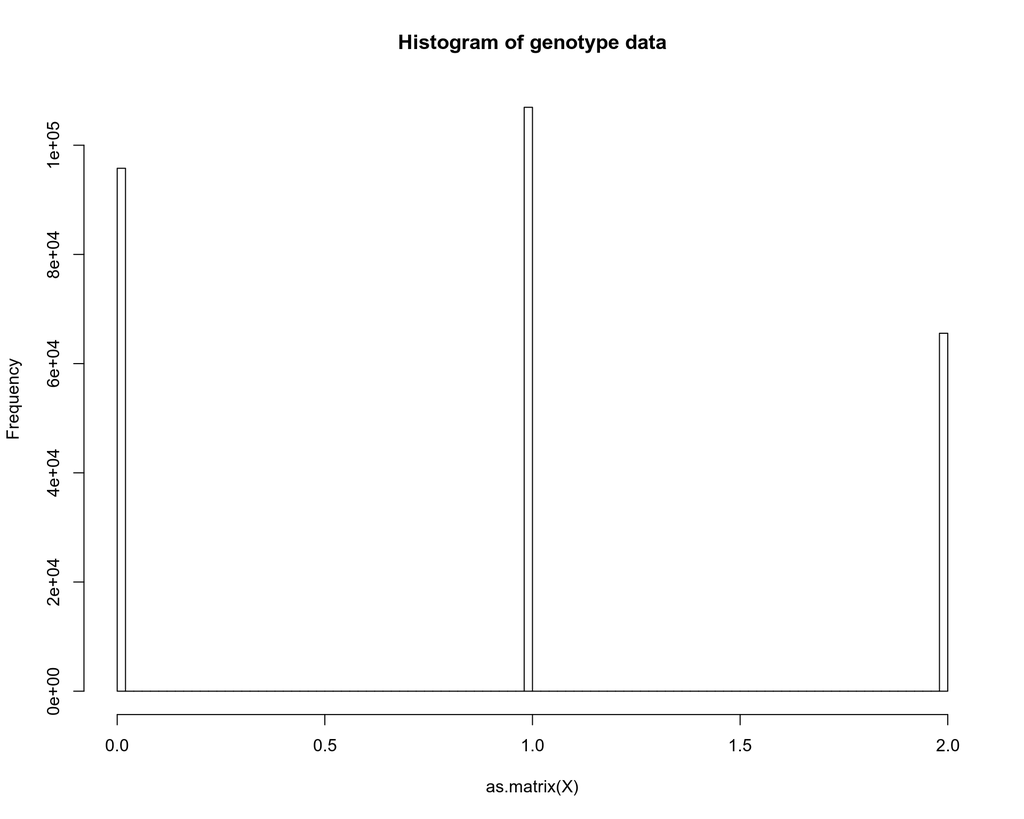

```r
library("mixOmics")
gen<-na.omit(gen)
X<-as.data.frame(t(gen))
hist(as.matrix(X), breaks = 100, main = "Histogram of genotype data")
```

```r
X[1:10,1:10]
```

```
##      rs1851946_A rs2455144_A rs2455137_G rs2500278_G rs12031275_G
## ID1            0           0           0           0            2
## ID3            1           2           2           2            0
## ID4            2           0           0           0            2
## ID6            0           0           0           0            0
## ID8            2           1           1           1            0
## ID10           1           0           0           0            0
## ID14           2           0           0           0            1
## ID19           0           1           1           1            1
## ID21           2           0           0           0            0
## ID30           1           0           0           0            0
##      rs912991_G rs707582_G rs1750838_G rs2781064_G rs663364_C
## ID1           1          2           1           2          2
## ID3           0          0           1           1          1
## ID4           2          1           0           1          1
## ID6           1          1           1           0          2
## ID8           0          0           0           2          2
## ID10          1          1           0           1          1
## ID14          2          0           0           2          0
## ID19          1          1           0           1          0
## ID21          2          1           2           0          1
## ID30          2          0           1           0          1
```

```r
dim(X)
```

```
## [1]  110 2439
```

```r
pca.gen<-pca(X, ncomp=10, center=TRUE, scale=TRUE)
pca.gen
```

```
## Eigenvalues for the first 10 principal components, see object$sdev^2:
##      PC1      PC2      PC3      PC4      PC5      PC6      PC7      PC8
## 42.00074 40.61893 36.87964 36.08494 35.31063 33.88292 33.27106 33.15289
##      PC9     PC10
## 32.47459 32.35497
##
## Proportion of explained variance for the first 10 principal components, see object$explained_variance:
##        PC1        PC2        PC3        PC4        PC5        PC6
## 0.01722048 0.01665393 0.01512080 0.01479497 0.01447750 0.01389214
##        PC7        PC8        PC9       PC10
## 0.01364127 0.01359282 0.01331471 0.01326567
##
## Cumulative proportion explained variance for the first 10 principal components, see object$cum.var:
##        PC1        PC2        PC3        PC4        PC5        PC6
## 0.01722048 0.03387441 0.04899521 0.06379018 0.07826769 0.09215982
##        PC7        PC8        PC9       PC10
## 0.10580109 0.11939391 0.13270863 0.14597430
##
##  Other available components:
##  --------------------
##  loading vectors: see object$rotation
```

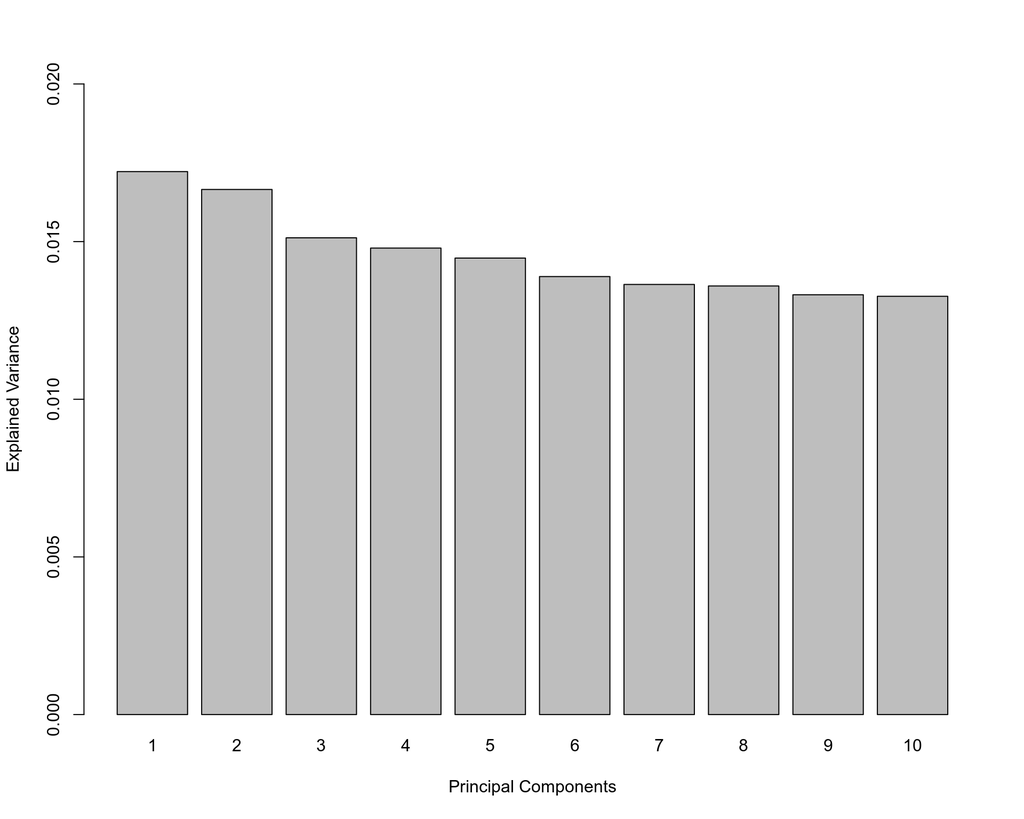

```r
plot(pca.gen,ylim=c(0,0.02))
```

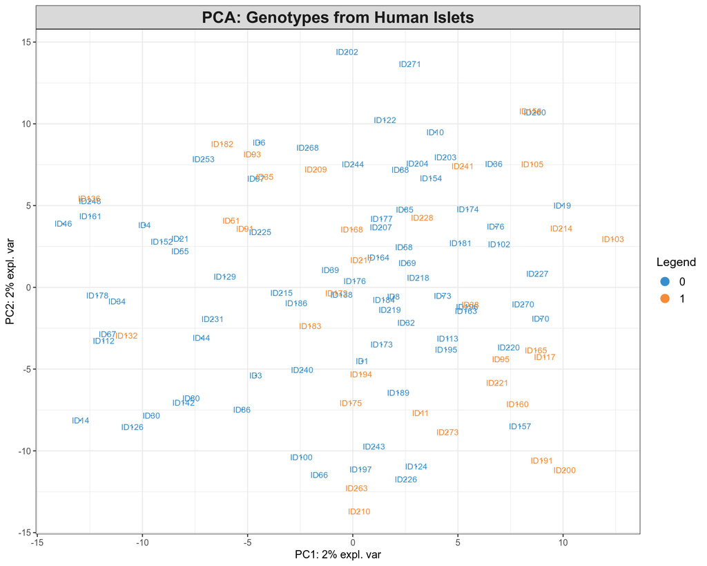

```r
plotIndiv(pca.gen,group=as.factor(htl$T2D),ind.names=TRUE,ellipse=FALSE,legend=TRUE,title="PCA: Genotypes from Human Islets")
```

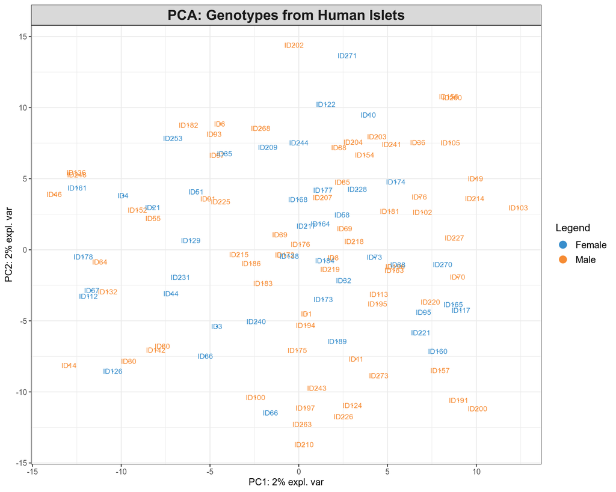

```r
plotIndiv(pca.gen,group=as.factor(htl$Gender),ind.names=TRUE,ellipse=FALSE,legend=TRUE,title="PCA: Genotypes from Human Islets")
```

```r
htl$DIC<-as.factor(htl$DIC)
htl$Meth_Batch<-as.factor(htl$Meth_Batch)
htl$RNA_Batch<-as.factor(htl$RNA_Batch)
pc_adj_r_squared<-matrix(NA,ncol=dim(pca.gen$x)[2],nrow=dim(htl)[2])
for(i in 1:dim(pca.gen$x)[2])
{
  print(i)
  for(j in 1:dim(htl)[2])
  {
    pc_adj_r_squared[j,i]<-summary(lm(pca.gen$x[,i]~htl[,j]))$adj.r.squared
  }
}
```

```
## [1] 1
## [1] 2
## [1] 3
## [1] 4
## [1] 5
## [1] 6
## [1] 7
## [1] 8
## [1] 9
## [1] 10
```

```r
pc_adj_r_squared<-as.data.frame(pc_adj_r_squared)
colnames(pc_adj_r_squared)<-colnames(pca.gen$x)
rownames(pc_adj_r_squared)<-colnames(htl)
pc_adj_r_squared[pc_adj_r_squared<0]<-0
pc_adj_r_squared
```

```
##                    PC1          PC2         PC3        PC4         PC5
## Gender     0.006082547 0.0000000000 0.000000000 0.02254328 0.000000000
## Age        0.046563662 0.0085817673 0.000000000 0.00000000 0.011809513
## BMI        0.000000000 0.0008204107 0.003017061 0.03691427 0.000000000
## HbA1c      0.039685958 0.0000000000 0.000000000 0.00000000 0.012841890
## T2D        0.034302460 0.0000000000 0.000000000 0.02435668 0.004865261
## SI         0.000000000 0.0000000000 0.000000000 0.00000000 0.000000000
## Purity     0.037578859 0.0000000000 0.000000000 0.00000000 0.000000000
## DIC        0.000000000 0.0102060165 0.000000000 0.00000000 0.037670760
## Meth_Batch 0.000000000 0.0241894605 0.046995787 0.02946732 0.000000000
## RNA_Batch  0.000000000 0.0000000000 0.000000000 0.00000000 0.000000000
## Random     0.000000000 0.0574632674 0.000000000 0.00000000 0.000000000
##                    PC6        PC7         PC8        PC9        PC10
## Gender     0.000000000 0.01423215 0.000000000 0.00000000 0.006638875
## Age        0.009180754 0.01978461 0.000000000 0.00000000 0.000000000
## BMI        0.000000000 0.00000000 0.000000000 0.00000000 0.000000000
## HbA1c      0.000000000 0.00000000 0.000000000 0.00000000 0.000000000
## T2D        0.000000000 0.01292809 0.000000000 0.00000000 0.000000000
## SI         0.000000000 0.00000000 0.000000000 0.00000000 0.003850540
## Purity     0.000000000 0.00000000 0.009522110 0.00000000 0.071679851
## DIC        0.061979202 0.00000000 0.014207136 0.00000000 0.000000000
## Meth_Batch 0.044492915 0.05925138 0.007033777 0.00000000 0.007277688
## RNA_Batch  0.007771840 0.00000000 0.000000000 0.00000000 0.000000000
## Random     0.000000000 0.00000000 0.009283433 0.01459895 0.000000000
```

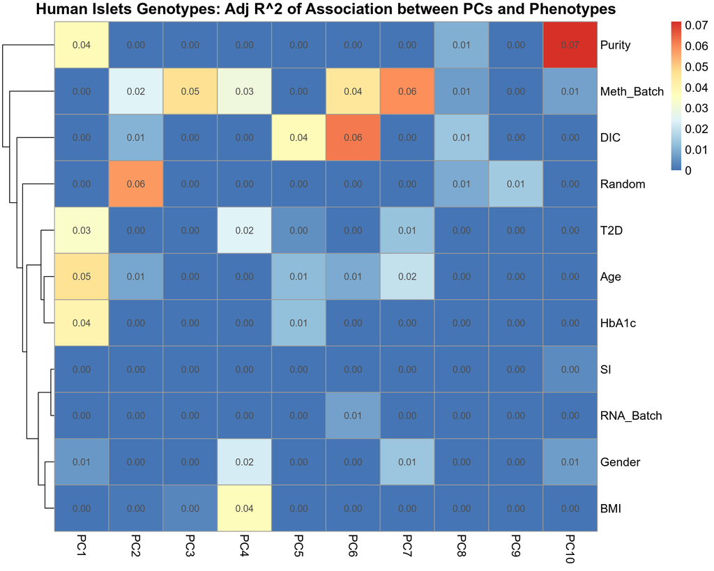

```r
library("pheatmap")
pheatmap(pc_adj_r_squared, display_numbers=TRUE, fontsize=12, cluster_cols=FALSE, main="Human Islets Genotypes: Adj R^2 of Association between PCs and Phenotypes")
```

The heatmap shows a promising contribution of T2D and HbA1c into the PC1. However, Purity seems to contribute to PC1 as well. Since T2D contributes to the PC1 it is informative to look at the top loading of PC1 to have some idea which genes drive this component:

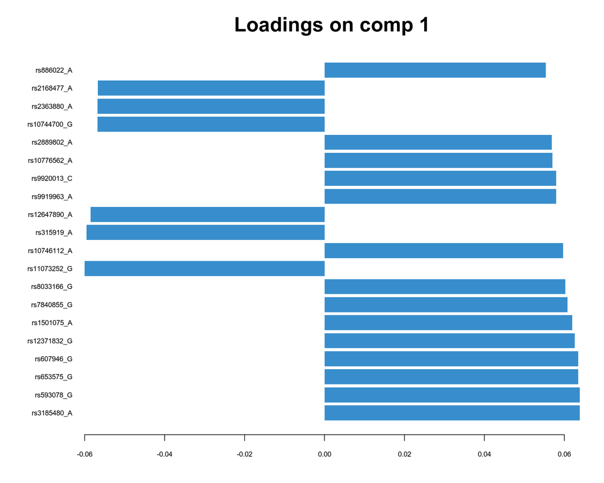

```r
plotLoadings(pca.gen,comp=1,method='median',contrib='max',ndisplay=20)
```

```r
head(sort(abs(pca.gen$loadings$X[,"PC1"]),decreasing=TRUE),20)
```

```
##  rs3185480_A   rs593078_G   rs653575_G   rs607946_G rs12371832_G
##   0.06388405   0.06388405   0.06347878   0.06347878   0.06260999
##  rs1501075_A  rs7840855_G  rs8033166_G rs11073252_G rs10746112_A
##   0.06200848   0.06077059   0.06021908   0.06003018   0.05970908
##   rs315919_A rs12647890_A  rs9919963_A  rs9920013_C rs10776562_A
##   0.05953748   0.05855759   0.05800427   0.05800427   0.05702854
##  rs2889802_A rs10744700_G  rs2363880_A  rs2168477_A   rs886022_A
##   0.05688904   0.05677241   0.05677241   0.05671228   0.05535020
```

### PLS-DA Analysis of Genotyping Array Data

Now we will perform PLS-DA analysis, for this purpose we are going to construct the X and Y matrices in order to maximize their covariance, cov(X,Y):

```r
gc()
```

```
##           used  (Mb) gc trigger  (Mb)  max used   (Mb)
## Ncells 1966736 105.1    3471220 185.4   3136634  167.6
## Vcells 8075524  61.7   94410036 720.3 147515676 1125.5
```

```r
library("mixOmics")
X<-as.data.frame(t(gen))
Y<-as.factor(as.character(htl$T2D))
summary(Y)
```

```
##  0  1
## 78 32
```

We have approximately 29% of T2D individuals which is not crazy unbalanced, so there is a hope that the model does not learn only the majority class. Important to mention that a very naive / stupid classifier that predicts Non-T2D for any given individual should thus achieve 71% accuracy of classification. So our PLS-DA model should be better than the naive classifier and outperform the lower threshold of 71%.

```r
my_folds=2
my_nrepeat=10
my_progressBar=FALSE
my_cpus=1
```

```r
gc()
```

```
##           used  (Mb) gc trigger  (Mb)  max used   (Mb)
## Ncells 1967001 105.1    3471220 185.4   3136634  167.6
## Vcells 8076632  61.7   75528029 576.3 147515676 1125.5
```

```r
gen_plsda.perf<-plsda(X, Y, ncomp=5)

ptm<-proc.time()
perf.plsda<-perf(gen_plsda.perf, validation='Mfold', folds=my_folds, progressBar=my_progressBar, nrepeat=my_nrepeat)
proc.time()-ptm
```

```
##    user  system elapsed
##   4.151   0.000   4.153
```

```r
perf.plsda
```

```
##
## Call:
##  perf.mixo_plsda(object = gen_plsda.perf, validation = "Mfold", folds = my_folds, nrepeat = my_nrepeat, progressBar = my_progressBar)
##
##  Main numerical outputs:
##  --------------------
##  Error rate (overall or BER) for each component and for each distance: see object$error.rate
##  Error rate per class, for each component and for each distance: see object$error.rate.class
##  Prediction values for each component: see object$predict
##  Classification of each sample, for each component and for each distance: see object$class
##  AUC values: see object$auc if auc = TRUE
##
##  Visualisation Functions:
##  --------------------
##  plot
```

```r
head(perf.plsda$error.rate)
```

```
## $overall
##        max.dist centroids.dist mahalanobis.dist
## comp1 0.2954545      0.2936364        0.2936364
## comp2 0.2963636      0.2963636        0.2963636
## comp3 0.2881818      0.2881818        0.2881818
## comp4 0.2945455      0.2945455        0.2945455
## comp5 0.2900000      0.2890909        0.2900000
##
## $BER
##        max.dist centroids.dist mahalanobis.dist
## comp1 0.4976763      0.4927083        0.4927083
## comp2 0.5020032      0.5020032        0.5020032
## comp3 0.4870192      0.4870192        0.4870192
## comp4 0.4997997      0.4997997        0.4997997
## comp5 0.4929087      0.4922676        0.4929087
```

```r
head(perf.plsda$error.rate.class)
```

```
## $max.dist
##        comp1      comp2      comp3       comp4       comp5
## 0 0.01410256 0.01025641 0.01153846 0.008974359 0.007692308
## 1 0.98125000 0.99375000 0.96250000 0.990625000 0.978125000
##
## $centroids.dist
##        comp1      comp2      comp3       comp4       comp5
## 0 0.01666667 0.01025641 0.01153846 0.008974359 0.006410256
## 1 0.96875000 0.99375000 0.96250000 0.990625000 0.978125000
##
## $mahalanobis.dist
##        comp1      comp2      comp3       comp4       comp5
## 0 0.01666667 0.01025641 0.01153846 0.008974359 0.007692308
## 1 0.96875000 0.99375000 0.96250000 0.990625000 0.978125000
```

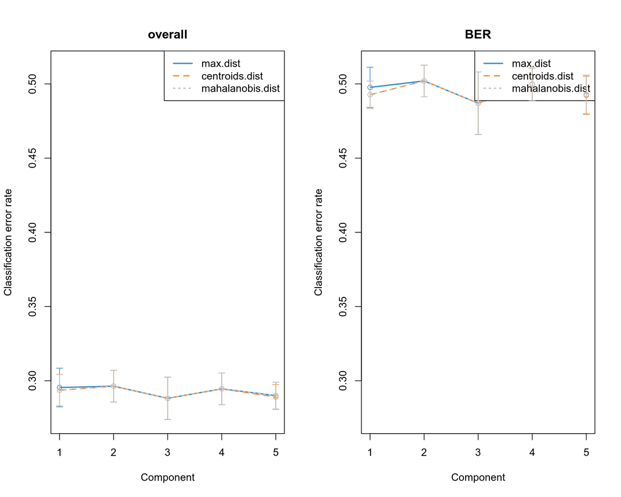

```r
plot(perf.plsda,overlay='dist',sd=TRUE)
```

BER Mahalanobis and max distances seem to reach their plateau or weak minimum at ncomp=3, so we will use 3 PLS components for further PLS-DA analysis.

```r
gc()
```

```
##           used  (Mb) gc trigger  (Mb)  max used   (Mb)
## Ncells 2016819 107.8    3471220 185.4   3471220  185.4
## Vcells 8661628  66.1   60422424 461.0 147515676 1125.5
```

```r
gen_plsda<-plsda(X, Y, ncomp=3)
gen_plsda$explained_variance
```

```
## $X
##     comp 1     comp 2     comp 3
## 0.01155515 0.01201312 0.01119458
##
## $Y
##     comp 1     comp 2     comp 3
## 1.00000000 0.10153491 0.01267553
```

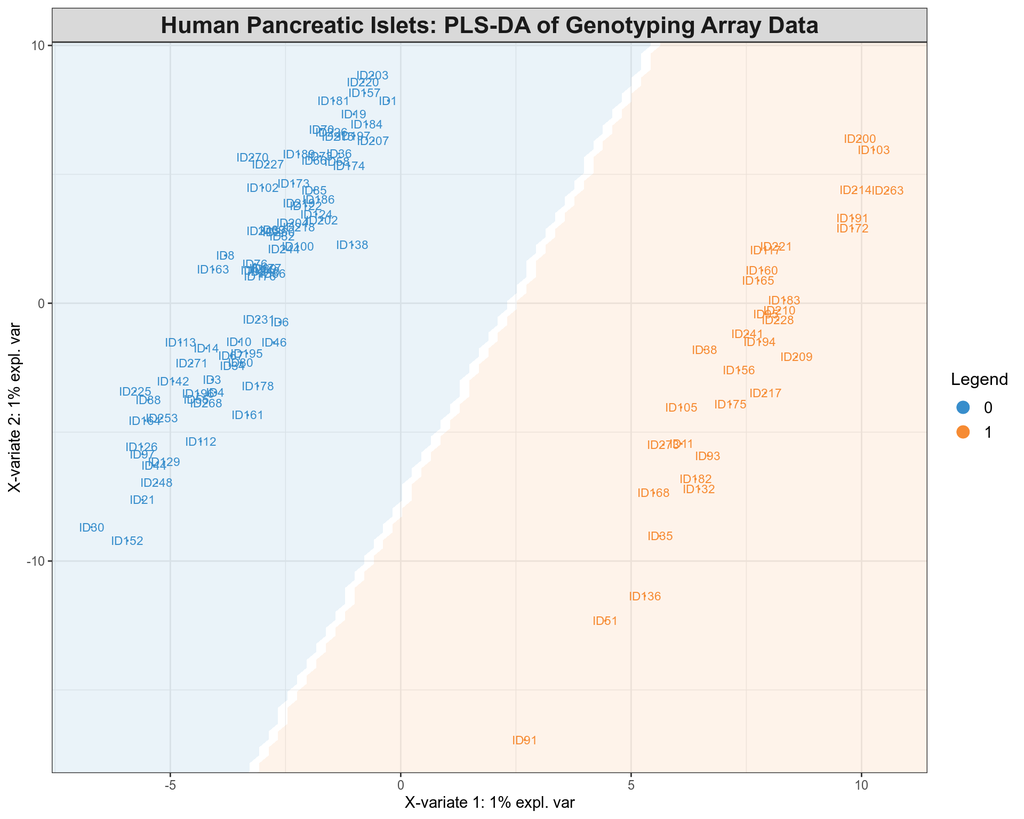

```r
background = background.predict(gen_plsda, comp.predicted=2, dist = "mahalanobis.dist")
plotIndiv(gen_plsda, comp=c(1,2), group=Y, ind.names=TRUE, ellipse=FALSE, background=background, legend=TRUE, title="Human Pancreatic Islets: PLS-DA of Genotyping Array Data")
```

Plotting the loadings of the two PLS components we can see which genes are responsible for the linear separation of the T2D and non-T2D individuals:

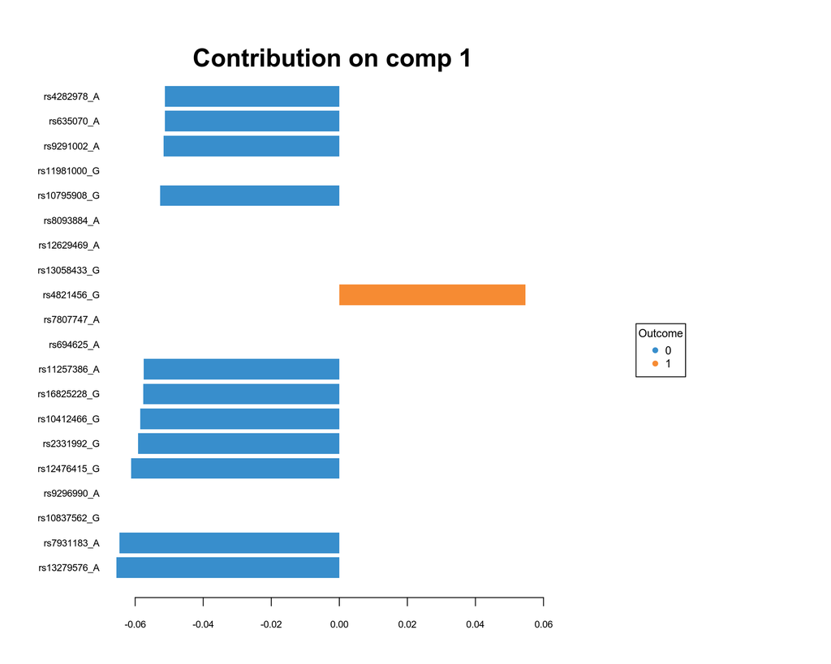

```r
plotLoadings(gen_plsda, comp=1, method='median', contrib='max', ndisplay=20)
```

```r
head(sort(abs(gen_plsda$loadings$X[,"comp1"]),decreasing=TRUE),10)
```

```
## rs13279576_A  rs7931183_A rs10837562_G  rs9296990_A rs12476415_G
##   0.06553447   0.06467205   0.06228699   0.06146152   0.06113517
##  rs2331992_G rs10412466_G rs16825228_G rs11257386_A   rs694625_A
##   0.05913204   0.05846528   0.05760545   0.05744278   0.05736891
```

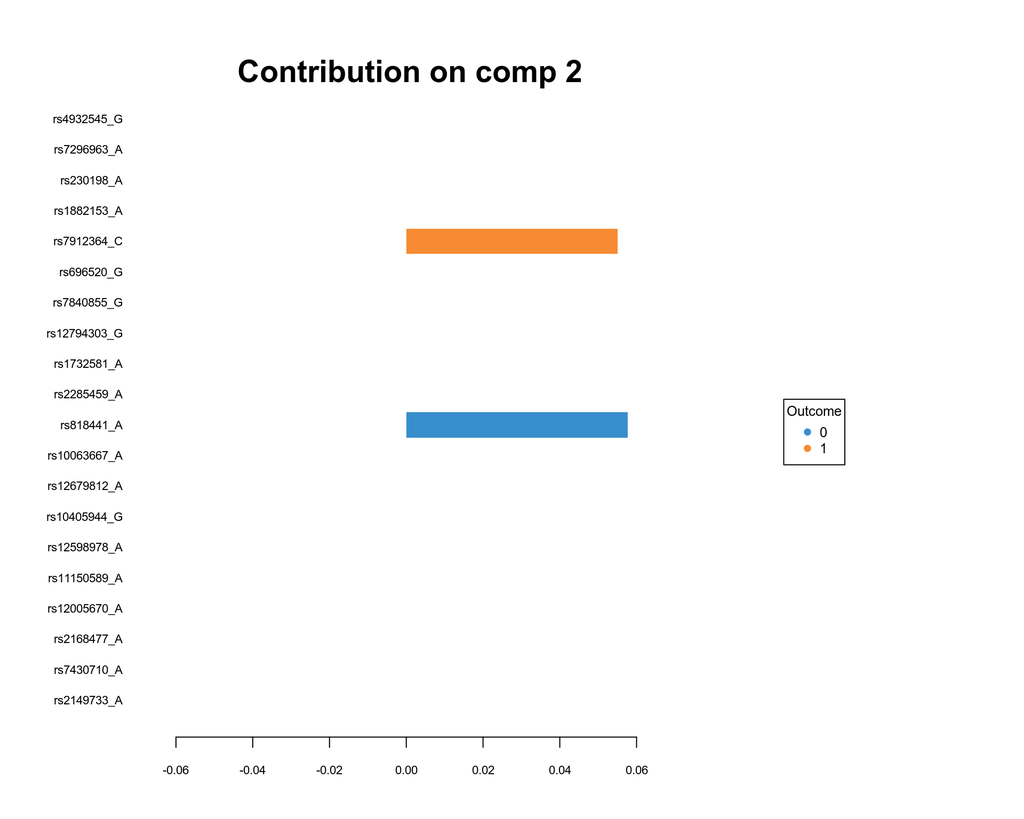

```r
plotLoadings(gen_plsda, comp=2, method='median', contrib='max', ndisplay=20)
```

```r
head(sort(abs(gen_plsda$loadings$X[,"comp2"]),decreasing=TRUE),10)
```

```
##  rs2149733_A  rs7430710_A  rs2168477_A rs12005670_A rs11150589_A
##   0.07023173   0.06892331   0.06849572   0.06455598   0.06423411
## rs12598978_A rs10405944_G rs12679812_A rs10063667_A   rs818441_A
##   0.06423411   0.06397365   0.06152849   0.06039210   0.05768990
```

### Sparse PLS-DA Analysis of Genotyping Array Data

Many of the variants included to the PLS-DA analysis are actually non-informative and bring noise to the analysis. Therefore one needs to apply sparse cleaning algorithm to select a subset of variants that best discriminate between diabetics and non diabetics. We will use LASSO for selection of most informative variants. The tuning procedure below is performed on one component at a time and selects an optimal number of genes that provide lowest error rate. Since from the previous analysis we concluded that the minimal error rate is achieved on the first 3 principal components, we will use ncomp=3 in the sPLS-DA analysis.

```r
gc()
```

```
##           used  (Mb) gc trigger  (Mb)  max used   (Mb)
## Ncells 2030898 108.5    3471220 185.4   3471220  185.4
## Vcells 9127072  69.7   38670352 295.1 147515676 1125.5
```

```r
list.keepX<-c(1:50)

ptm<-proc.time()
tune.splsda.islets<-tune.splsda(X,Y,ncomp=3,validation='Mfold',folds=my_folds,progressBar=my_progressBar,dist='mahalanobis.dist',test.keepX=list.keepX,nrepeat=my_nrepeat)
proc.time()-ptm
```

```
##    user  system elapsed
##  50.622   0.036  50.672
```

```r
head(tune.splsda.islets$error.rate)
```

```
##       comp1     comp2     comp3
## 1 0.5068910 0.5075321 0.5014022
## 2 0.5181891 0.5203125 0.4910256
## 3 0.5012420 0.5196715 0.4897436
## 4 0.5042869 0.5119792 0.4865385
## 5 0.5062099 0.5207131 0.4917869
## 6 0.5076923 0.5194311 0.4971154
```

```r
tune.splsda.islets$choice.keepX
```

```
## comp1 comp2 comp3
##    10     1     4
```

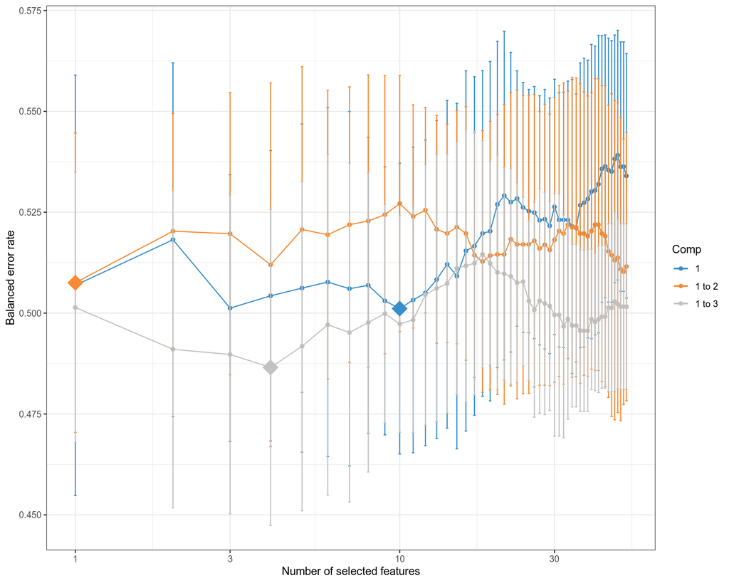

```r
plot(tune.splsda.islets,optimal=TRUE,sd=TRUE)
```

```r
gc()
```

```
##           used  (Mb) gc trigger  (Mb)  max used   (Mb)
## Ncells 2042157 109.1    3471220 185.4   3471220  185.4
## Vcells 9144589  69.8   30936282 236.1 147515676 1125.5
```

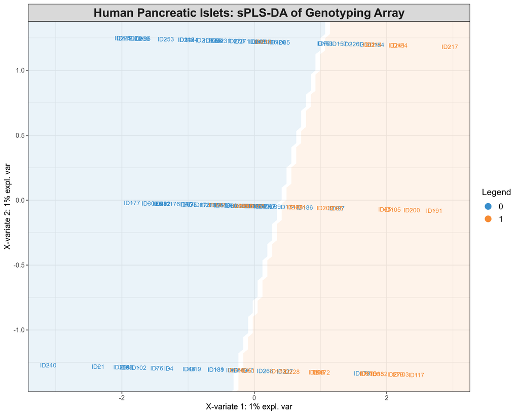

```r
select.keepX<-as.numeric(tune.splsda.islets$choice.keepX)
splsda.islets<-splsda(X, Y, ncomp=3, keepX=select.keepX)
background = background.predict(splsda.islets, comp.predicted=2, dist = "mahalanobis.dist")
plotIndiv(splsda.islets,comp=c(1,2),group=Y,ind.names=TRUE,ellipse=FALSE,background=background,legend=TRUE,title="Human Pancreatic Islets: sPLS-DA of Genotyping Array")
```

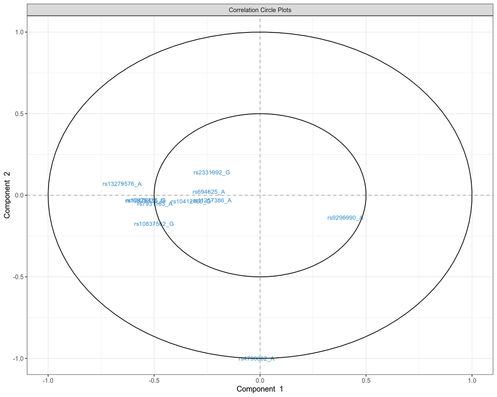

```r
plotVar(splsda.islets,comp=c(1,2),var.names=list(rownames(gen)),cex=3)
```

```r
head(sort(abs(splsda.islets$loadings$X[,"comp1"]),decreasing=TRUE),10)
```

```
## rs13279576_A  rs7931183_A rs10837562_G  rs9296990_A rs12476415_G
##   0.55854833   0.50922940   0.37283478   0.32562879   0.30696565
##  rs2331992_G rs10412466_G rs16825228_G rs11257386_A   rs694625_A
##   0.19241280   0.15428288   0.10511137   0.09580915   0.09158443
```

```r
head(sort(abs(splsda.islets$loadings$X[,"comp2"]),decreasing=TRUE),10)
```

```
##  rs4790082_A  rs1851946_A  rs2455144_A  rs2455137_G  rs2500278_G
##            1            0            0            0            0
## rs12031275_G   rs912991_G   rs707582_G  rs1750838_G  rs2781064_G
##            0            0            0            0            0
```

```
## 'ndisplay' value is larger than the number of selected variables! It has been reseted to 10 for block X
```

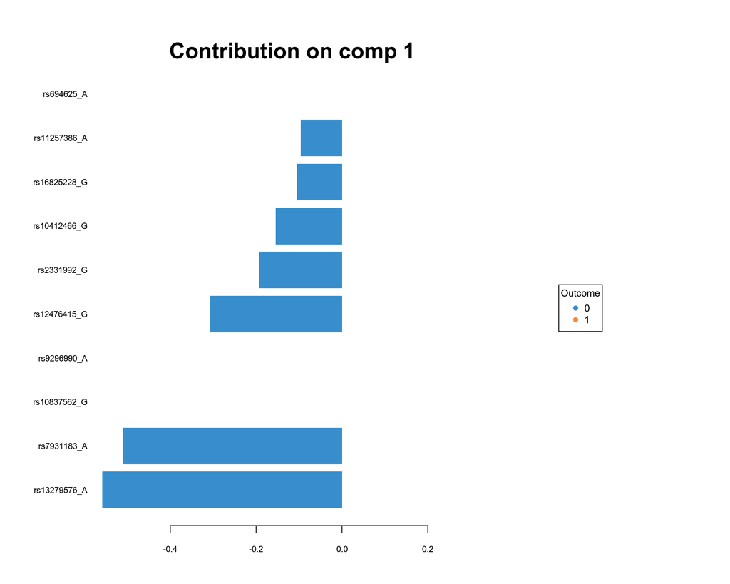

```r
plotLoadings(splsda.islets,comp=1,method='median',contrib='max',ndisplay=20)
```

```
## 'ndisplay' value is larger than the number of selected variables! It has been reseted to 1 for block X
```

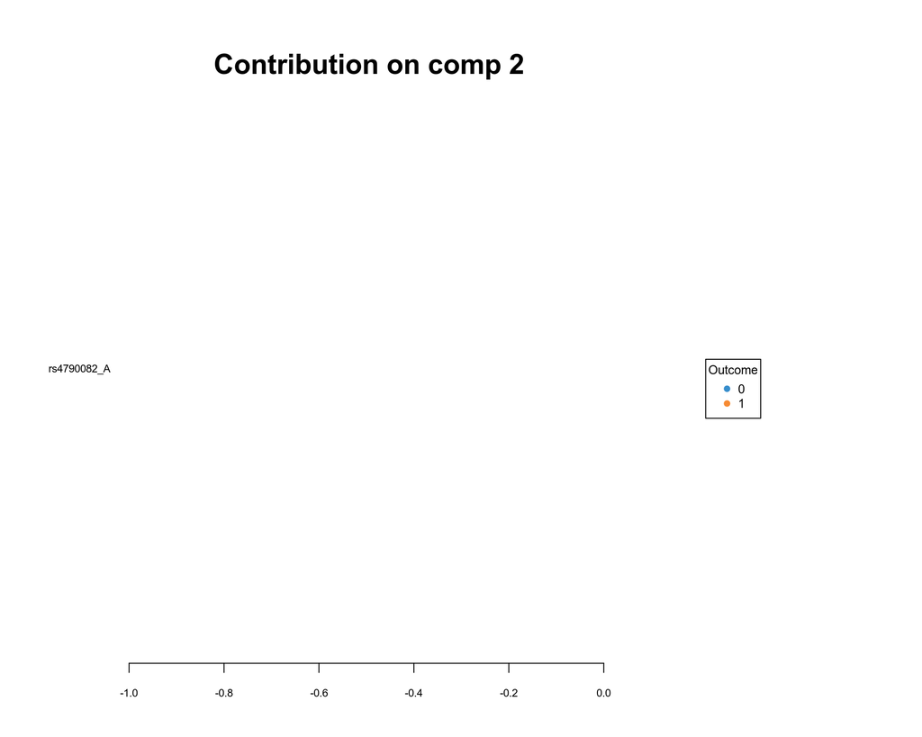

```r
plotLoadings(splsda.islets,comp=2,method='median',contrib='max',ndisplay=20)
```

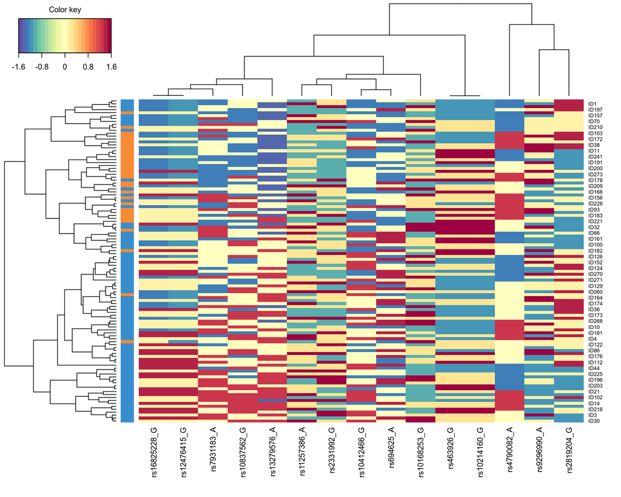

```r
cim(splsda.islets,row.sideColors=color.mixo(Y),margins=c(8,4))
```

### Predicting T2D Status from sPLS-DA Model

Finally we will randomly split the Ggenotyping Array data set into training (80% of samples) and validation (20% of samples) sets. This is needed to validate predictions of sPLS-DA trained on the training data set.

```r
gc()
```

```
##           used  (Mb) gc trigger  (Mb)  max used   (Mb)
## Ncells 2095126 111.9    3471220 185.4   3471220  185.4
## Vcells 9692894  74.0   30936282 236.1 147515676 1125.5
```

```r
N_repeat<-100
comp1_acc<-vector()
comp2_acc<-vector()
#test_samples<-selected_ind[sample(1:length(selected_ind),round(length(selected_ind)*0.2))]
#train_samples<-selected_ind[!selected_ind%in%test_samples]
for(k in 1:N_repeat)
{
  print(paste0("Working with split No.", k))
  gc()
  set.seed(k+100)
  test_samples<-colnames(gen)[sample(1:length(colnames(gen)),round(length(colnames(gen))*0.2))]
  train_samples<-colnames(gen)[!colnames(gen)%in%test_samples]

  X.train<-X[match(train_samples,rownames(X)),]
  X.test<-X[match(test_samples,rownames(X)),]
  Y.train<-as.factor(as.character(htl[match(train_samples,rownames(htl)),]$T2D))
  Y.test<-as.factor(as.character(htl[match(test_samples,rownames(htl)),]$T2D))

  list.keepX<-c(1:50)
  tune.splsda.train.gen<-tune.splsda(X.train, Y.train, ncomp=3, validation='Mfold', folds=my_folds,
                                     progressBar=my_progressBar, dist='mahalanobis.dist', logratio="none",
                                     test.keepX=list.keepX, nrepeat=my_nrepeat)
  splsda.gen.train<-splsda(X.train, Y.train, logratio='none', ncomp=3,
                           keepX=as.numeric(tune.splsda.train.gen$choice.keepX))

  splsda.gen.predict<-predict(splsda.gen.train, X.test, dist='mahalanobis.dist')

  print(table(splsda.gen.predict$class$mahalanobis.dist[,1],Y.test))
  acc1<-round((sum(diag(table(splsda.gen.predict$class$mahalanobis.dist[,1],Y.test)))/sum(table(splsda.gen.predict$class$mahalanobis.dist[,1],Y.test)))*100)
  print(paste0("Classification Accuracy from PLS Component 1: ", acc1))
  print(table(splsda.gen.predict$class$mahalanobis.dist[,2],Y.test))
  acc2<-round((sum(diag(table(splsda.gen.predict$class$mahalanobis.dist[,2],Y.test)))/sum(table(splsda.gen.predict$class$mahalanobis.dist[,2],Y.test)))*100)
  print(paste0("Classification Accuracy from PLS Component 2: ", acc2))

  comp1_acc<-append(comp1_acc,acc1)
  comp2_acc<-append(comp2_acc,acc2)
  print("***********************************************************")
}
```

```
## [1] "Working with split No.1"
##    Y.test
##     0 1
##   0 7 6
##   1 7 2
## [1] "Classification Accuracy from PLS Component 1: 41"
##    Y.test
##     0 1
##   0 8 7
##   1 6 1
## [1] "Classification Accuracy from PLS Component 2: 41"
## [1] "***********************************************************"
## [1] "Working with split No.2"
##    Y.test
##      0  1
```

[output cut: 1185 more lines]

```r
write.table(comp1_acc,file="Comp1_PLS_Gen_Acc.txt",col.names=FALSE,row.names=FALSE,quote=FALSE,sep="\t")
write.table(comp2_acc,file="Comp2_PLS_Gen_Acc.txt",col.names=FALSE,row.names=FALSE,quote=FALSE,sep="\t")
```

```r
gc()
```

```
##            used  (Mb) gc trigger  (Mb)  max used   (Mb)
## Ncells  2101503 112.3    3471271 185.4   3471271  185.4
## Vcells 10223515  78.0   30936282 236.1 147515676 1125.5
```

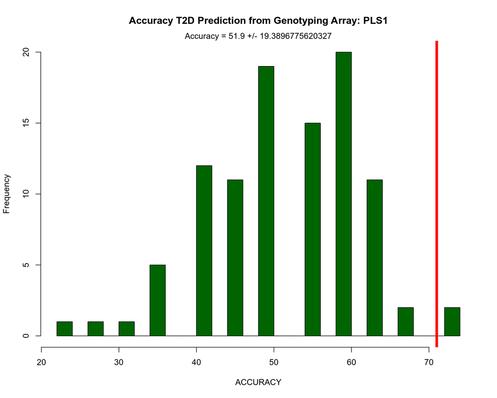

```r
comp1_acc_arch<-as.numeric(scan("Comp1_PLS_Gen_Acc.txt",what="character"))
comp2_acc_arch<-as.numeric(scan("Comp2_PLS_Gen_Acc.txt",what="character"))

#comp1_acc_arch<-c(comp1_acc,comp1_acc_arch)
#comp2_acc_arch<-c(comp2_acc,comp2_acc_arch)

hist(comp1_acc_arch,breaks=20,xlab="ACCURACY",main="Accuracy T2D Prediction from Genotyping Array: PLS1",col="darkgreen")
abline(v=71,col="red",lwd=5)
mtext(paste0("Accuracy = ",mean(comp1_acc_arch)," +/- ",2*sd(comp1_acc_arch)))
```

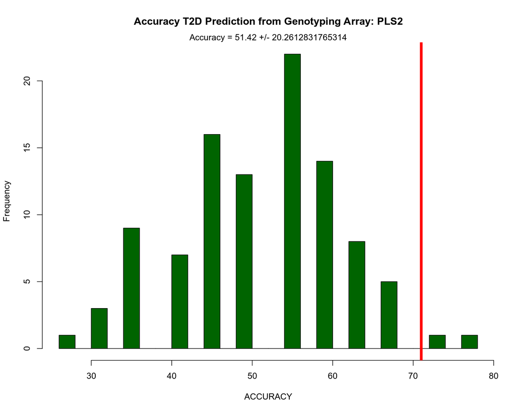

```r
hist(comp2_acc_arch,breaks=20,xlab="ACCURACY",main="Accuracy T2D Prediction from Genotyping Array: PLS2",col="darkgreen")
abline(v=71,col="red",lwd=5)
mtext(paste0("Accuracy = ",mean(comp2_acc_arch)," +/- ",2*sd(comp2_acc_arch)))
```

We can compute how significantly different is the accuracy of the PLS-DA model compared to the naive 71% accuracy:

```r
gc()
```

```
##            used  (Mb) gc trigger  (Mb)  max used   (Mb)
## Ncells  2101544 112.3    3471271 185.4   3471271  185.4
## Vcells 10222993  78.0   30936282 236.1 147515676 1125.5
```

```r
sum(comp1_acc_arch<=71)/length(comp1_acc_arch)
```

```
## [1] 0.98
```

```r
sum(comp2_acc_arch<=71)/length(comp2_acc_arch)
```

```
## [1] 0.98
```

```r
rm(list=ls())
gc()
```

```
##           used  (Mb) gc trigger  (Mb)  max used   (Mb)
## Ncells 2092688 111.8    3471271 185.4   3471271  185.4
## Vcells 8200920  62.6   30936282 236.1 147515676 1125.5
```